# A7: Kickstarters

Author

Faruk Altun

Published

February 27, 2026

## Loading the Libraries

```r
library(dplyr)
library(ggplot2)
```

```r
#list.files("Desktop")
getwd()
```

```
[1] "/Users/farukferitaltun/Desktop"
```

## Loading the data

```r
ks_rd <- read.csv("~/Desktop/ks-projects-201801.csv", stringsAsFactors = FALSE)
ks_rd <- ks_rd
glimpse(ks_rd)
```

```
Rows: 378,661
Columns: 15
$ ID               <int> 1000002330, 1000003930, 1000004038, 1000007540, 10000…
$ name             <chr> "The Songs of Adelaide & Abullah", "Greeting From Ear…
$ category         <chr> "Poetry", "Narrative Film", "Narrative Film", "Music"…
$ main_category    <chr> "Publishing", "Film & Video", "Film & Video", "Music"…
$ currency         <chr> "GBP", "USD", "USD", "USD", "USD", "USD", "USD", "USD…
$ deadline         <chr> "2015-10-09", "2017-11-01", "2013-02-26", "2012-04-16…
$ goal             <dbl> 1000, 30000, 45000, 5000, 19500, 50000, 1000, 25000, …
$ launched         <chr> "2015-08-11 12:12:28", "2017-09-02 04:43:57", "2013-0…
$ pledged          <dbl> 0.00, 2421.00, 220.00, 1.00, 1283.00, 52375.00, 1205.…
$ state            <chr> "failed", "failed", "failed", "failed", "canceled", "…
$ backers          <int> 0, 15, 3, 1, 14, 224, 16, 40, 58, 43, 0, 100, 0, 0, 7…
$ country          <chr> "GB", "US", "US", "US", "US", "US", "US", "US", "US",…
$ usd.pledged      <dbl> 0.00, 100.00, 220.00, 1.00, 1283.00, 52375.00, 1205.0…
$ usd_pledged_real <dbl> 0.00, 2421.00, 220.00, 1.00, 1283.00, 52375.00, 1205.…
$ usd_goal_real    <dbl> 1533.95, 30000.00, 45000.00, 5000.00, 19500.00, 50000…
```

## Processing the Data

```r
ks_df <- ks_rd %>%
  mutate(
    deadline_date = as.Date(substr(deadline, 1, 10)),
    launched_date = as.Date(substr(launched, 1, 10)),
    deadline_year = as.integer(format(deadline_date, "%Y")),
    launched_year = as.integer(format(launched_date, "%Y"))
  )
glimpse(ks_df)
```

```
Rows: 378,661
Columns: 19
$ ID               <int> 1000002330, 1000003930, 1000004038, 1000007540, 10000…
$ name             <chr> "The Songs of Adelaide & Abullah", "Greeting From Ear…
$ category         <chr> "Poetry", "Narrative Film", "Narrative Film", "Music"…
$ main_category    <chr> "Publishing", "Film & Video", "Film & Video", "Music"…
$ currency         <chr> "GBP", "USD", "USD", "USD", "USD", "USD", "USD", "USD…
$ deadline         <chr> "2015-10-09", "2017-11-01", "2013-02-26", "2012-04-16…
$ goal             <dbl> 1000, 30000, 45000, 5000, 19500, 50000, 1000, 25000, …
$ launched         <chr> "2015-08-11 12:12:28", "2017-09-02 04:43:57", "2013-0…
$ pledged          <dbl> 0.00, 2421.00, 220.00, 1.00, 1283.00, 52375.00, 1205.…
$ state            <chr> "failed", "failed", "failed", "failed", "canceled", "…
$ backers          <int> 0, 15, 3, 1, 14, 224, 16, 40, 58, 43, 0, 100, 0, 0, 7…
$ country          <chr> "GB", "US", "US", "US", "US", "US", "US", "US", "US",…
$ usd.pledged      <dbl> 0.00, 100.00, 220.00, 1.00, 1283.00, 52375.00, 1205.0…
$ usd_pledged_real <dbl> 0.00, 2421.00, 220.00, 1.00, 1283.00, 52375.00, 1205.…
$ usd_goal_real    <dbl> 1533.95, 30000.00, 45000.00, 5000.00, 19500.00, 50000…
$ deadline_date    <date> 2015-10-09, 2017-11-01, 2013-02-26, 2012-04-16, 2015…
$ launched_date    <date> 2015-08-11, 2017-09-02, 2013-01-12, 2012-03-17, 2015…
$ deadline_year    <int> 2015, 2017, 2013, 2012, 2015, 2016, 2014, 2016, 2014,…
$ launched_year    <int> 2015, 2017, 2013, 2012, 2015, 2016, 2014, 2016, 2014,…
```

## Initial Calculations

```r
total_projects <- nrow(ks_df)

num_successful <- ks_df %>%
  filter(tolower(trimws(state)) == "successful") %>%
  nrow()

num_failed <- ks_df %>%
  filter(tolower(trimws(state)) == "failed") %>%
  nrow()

pct_failed <- round((num_failed / total_projects) * 100, 2)
pct_succeed <- round((num_successful / total_projects) * 100, 2)

cat("total_projects:", total_projects, "\n")
```

```
total_projects: 378661
```

```r
cat("num_successful:", num_successful, "\n")
```

```
num_successful: 133956
```

```r
cat("num_failed:", num_failed, "\n")
```

```
num_failed: 197719
```

```r
cat("pct_failed:", pct_failed, "\n")
```

```
pct_failed: 52.22
```

```r
cat("pct_succeed:", pct_succeed)
```

```
pct_succeed: 35.38
```

## Biggest Non-Success

```r
biggest_non_sense <- ks_df %>%
  filter(tolower(trimws(state)) != "successful") %>%
  arrange(desc(usd_pledged_real)) %>%
  slice(1)

biggest_non_sense
```

```
         ID                                                    name   category
1 414157650 The Skarp Laser Razor: 21st Century Shaving (Suspended) Technology
  main_category currency   deadline   goal            launched pledged
1    Technology      USD 2015-10-19 160000 2015-09-21 23:32:34 4005111
      state backers country usd.pledged usd_pledged_real usd_goal_real
1 suspended   20632      US     4005111          4005111        160000
  deadline_date launched_date deadline_year launched_year
1    2015-10-19    2015-09-21          2015          2015
```

### Explanation:

They gained more than 4 million dollars of pledge in less than 3 weeks but they were cancelled by Kickstarters due to violation of rules. Within hours of suspension they launched a new campaign and raised over 500,000 dollars claiming the device would be released by march 2016. However, from an update released by Skarp in june 2019, the razor was still under development and hadn’t entered production.

## Project State

```r
state_summary <- ks_df %>%
  group_by(state) %>%
  summarise(count = n(), .groups = "drop")
state_summary
```

```
# A tibble: 6 × 2
  state       count
  <chr>       <int>
1 canceled    38779
2 failed     197719
3 live         2799
4 successful 133956
5 suspended    1846
6 undefined    3562
```

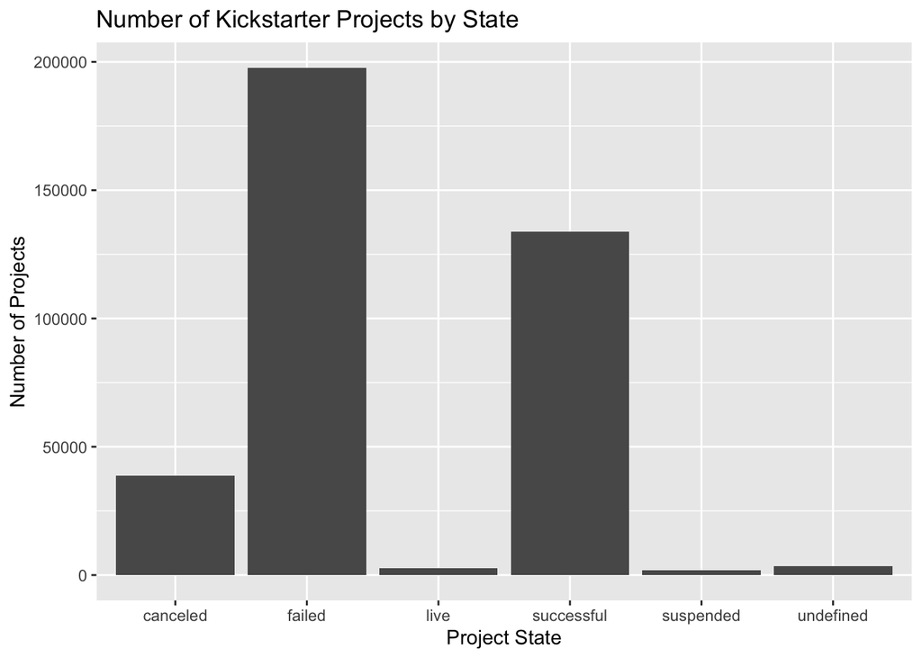

```r
ggplot(state_summary, aes(x = state, y = count)) +
  geom_col() +
  labs(
    title = "Number of Kickstarter Projects by State",
    x = "Project State",
    y = "Number of Projects"
  )
```

### Observation:

I think that the amount of successful projects are incredible. It is not even the half of the projects but %35 is a great number. It means that every 1 of 3 project is succeed.

## Yearly Summary

```r
year_summary <- ks_df %>%
  group_by(launched_year) %>%
  summarize(
    count = n(),
    success_count = sum(tolower(trimws(state)) == "successful"),
    percent_success = (success_count / count) * 100,
    mean_usd_pledged = mean(`usd.pledged`, na.rm = TRUE),
    .groups = "drop"
  )

print(year_summary)
```

```
# A tibble: 11 × 5
   launched_year count success_count percent_success mean_usd_pledged
           <int> <int>         <int>           <dbl>            <dbl>
 1          1970     7             0             0                 0
 2          2009  1329           579            43.6            2141.
 3          2010 10519          4593            43.7            2800.
 4          2011 26237         12171            46.4            3954.
 5          2012 41165         17892            43.5            7833.
 6          2013 44851         19415            43.3           10675.
 7          2014 67745         21107            31.2            7767.
 8          2015 77300         20971            27.1            9127.
 9          2016 57184         18766            32.8            6553.
10          2017 52200         18462            35.4            2414.
11          2018   124             0             0               441.
```

### Explanation:

I used launched_year because it represents when the project began, which makes more sense for analyzing yearly trends.I also wanted to sue the successful projects so I counted those and used the usd.pledged to summarize pledge amounts becuase it gives a yearly average

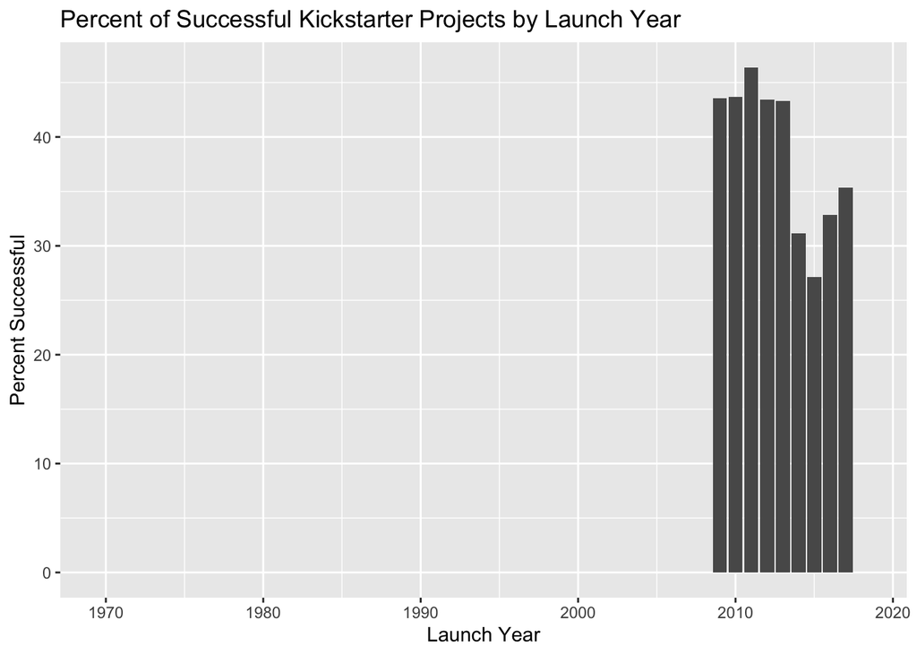

```r
ggplot(year_summary, aes(x = launched_year, y = percent_success)) +
  geom_col() +
  labs(
    title = "Percent of Successful Kickstarter Projects by Launch Year",
    x = "Launch Year",
    y = "Percent Successful"
  )
```

## Unusual data values

I don’t know why would they label some datas’ state as “undefined” or “live”? This is not giving us the total of succeeded or failed data. Some projects could be done and succeeded right after this data was pulled. I think some projects may not be completed when the dataset was created and because of that there are some weird graphs we are seen. I would ask what is qualified as “undefined” at what stage you are being undefined? Why would there be a cancelled section and failed section. Is it the kickstarters cancelling the projet or the developers?